# Deep Probabilistic Causal Modelling in Pyro

**Logan Graham**

Machine Learning Research Group

17 January 2019

# What is Pyro?

Pyro is a probabilistic programming language (PPL) intended to make it easy to integrate **deep learning** with **probabilistic methods**.

You:

1. Write a graphical model
2. Define your estimators (deep / not-deep) as part of the model
3. Choose inference method (MCMC / VI)
- It's built **on top of PyTorch**, which makes gradient-based Bayesian deep learning easy
- Additionally, it appears that its inference primitives make writing your own inference procedures straightforward

## In comparison

1. vs. **PyMC3** and **STAN**: same MCMC techniques + variational inference + deep model integration + write intuitively in Python
2. vs. **Edward**: dynamic computational graph creation + models are Python functions + intuitive

# Building Deep Probabilistic Models in Pyro

1. Say we're going to use some arbitrary nonlinear estimator:

```python
import torch
from torch import nn

class MLP(nn.Module):
    def __init__(self, dim, h):
        # define network params
        super(MLP, self).__init__()
        self.lin1 = nn.Linear(dim, h)
        self.lin2 = nn.Linear(h, 1)

    def forward(self, x):
        # define forward pass
        h1 = nn.functional.relu(self.lin1(x))
        return self.lin2(h1)

net = MLP(dim + 1, h=5)
```

We're going to turn it into a probabilistic model:

```python
def make_net_probabilistic(net, p, h):
    w1_prior = dist.Normal(torch.zeros(p), torch.ones(p)).to_event(1)
    b1_prior = dist.Normal(torch.zeros(1), torch.ones(1)).to_event(1)
    w2_prior = dist.Normal(torch.zeros(h), torch.ones(h)).to_event(1)
    b2_prior = dist.Normal(torch.zeros(1), torch.ones(1)).to_event(1)

    priors = {'lin1.weight': w1_prior, 'lin1.bias': b1_prior,
              'lin2.weight': w2_prior, 'lin2.bias': b2_prior}

    lifted_net = pyro.random_module("module", net, priors)
    return lifted_net()
```

Then build your model with `pyro.sample()` and `pyro.param()` statements:

```python
import pyro
import pyro.distributions as dist

def model(X, y, k=3, h=5):
    """
    Some arbitrary model
    """
    n, p = X.shape
    z_dist = pyro.sample("z_dist", dist.Dirichlet(torch.ones(k)))  # assume k components
    locs = pyro.param("locs", torch.ones(k))  # each with some mean
    sigma = pyro.param("sigma", dist.LogNormal(1, 1).sample())  # additive global variance
    net = MLP()
    net = make_net_probabilistic(net, p, h)
    with pyro.plate("data", n):  # used to indicate conditional independence
        z = pyro.sample("z", dist.Categorical(z_dist))  # each datapoint has some latent component
        z_embed = pyro.sample("z_embed", dist.Normal(locs[z], 1))  # its latent embedding
        d = torch.cat((z, X))
        y = pyro.sample("y", dist.Normal(net(d), obs=y))  # gaussian likelihood around nonlinear mean w/ embedding
```

Then define a guide, or a variational distribution:

```python
from torch.distributions.constraints import simplex, positive

def guide(X, y, k=3, h=5):
    """
    The guide model representing a chosen variational distribution.
    All non-observed sample statements have to be included with the same name.
    """
    n, p = X.shape
    z_dist = pyro.sample("z_dist", dist.Dirichlet(torch.ones(k)), constraint=simplex)
    locs = pyro.param("locs", torch.ones(k))
    sigma = pyro.param("sigma", dist.LogNormal(1, 1).sample(), constraint=positive)
    with pyro.plate("data", n)
        z = pyro.sample("z", dist.Categorical(z_dist))
        z_embed = pyro.sample("z_embed", dist.Normal(locs[z], 1))
```

Then run inference:

```python
optim = pyro.optim.SGD({'lr':1e-4, 'momentum':1e-1})  # choose an optimizer of choice
loss = pyro.infer.Trace_ELBO()  # choose an objective of choice
svi = pyro.infer.SVI(model, guide, optim, loss)

n_steps = 5000
for _ in range(n_steps):
    loss = svi.step(X, y)
```

## In summary:

1. Define model
2. Put in your estimators
3. Define a variational distribution
4. Run inference

# Causal Inference with Pyro

1. We're interested in the **treatment effect** given some **intervention**, $do(X=x)$:

$$TE = P(Y | do(X=x))$$

e.g.: *What's the effect on a patient's heart rate if I give them drug $x$? otherwise:* $P(Heart\ rate\ |\ give\ drug\ x)$

An **intervention** fixes the value of a variable, holding all other nodes equal.

### Usually, we we'd consider the conditional distribution:

$TE \approx P(Y | X=x)$

[figure not shown]

We define the model...

```python
def model():
    Z = pyro.sample("Z", dist.Bernoulli(0.5))
    X = pyro.sample("X", dist.Bernoulli(Z))
    return pyro.sample("Y", dist.Bernoulli(X + Z))
```

And now we see if the conditional model and the interventional model have the same distributions.

```python
def conditioned_model(model, x, n=1):
    return pyro.condition(model, data={"X": x})()

def intervened_model(model, x):
    return pyro.do(model, data={'X': x})()

x_value = 0.
```

...and we see that in the presence of confounding, the **interventional distribution** is different from the **conditional distribution**.

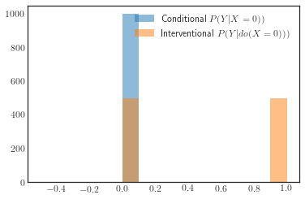

```python
import matplotlib.pyplot as plt
%matplotlib inline

plt.style.use("seaborn-white")
plt.hist(conditional_distribution, alpha=0.5, label='Conditional $P(Y | X=0))$')
plt.hist(intervened_distribution, alpha=0.5, label='Interventional $P(Y | do(X=0)))$')
# plt.hist(cond_dn, alpha=0.5, label='Conditional')
# plt.hist(int_dn, alpha=0.5, label='Interventional')
plt.legend()
```

...thus $P(Y|X) \neq P(Y|do(X))$, so fitting a function naively $Y = f(X)$ will be **confounded** or **biased**.

Instead, we need someway to recover the unconfounded function.

Let's build a bayesian model in Pyro leveraging deep models based on the assumption that some $f: X \rightarrow Y$ is complex, and then perform an intervention to recover the interventional distribution.

## Debiasing with Instrumental Variables

[figure not shown]

```python
# let's generate some synthetic data
n = 1000
U = dist.LogNormal(0, 1).sample((n,)).reshape(-1, 1) / 3.
Z = dist.Normal(0, 1).sample((n,)).reshape(-1, 1)
coefs = torch.tensor([7., 2.])
X = torch.matmul(torch.cat((U, Z), 1), coefs).reshape(-1, 1)
Y = torch.matmul(torch.cat((X, U), 1), torch.tensor([4., 10.])) # true treatment effect is 4*x
noise = dist.Normal(0, 0.15).sample((n,))
Y = Y + noise
observed_data = torch.cat((Z, X, Y.reshape(-1, 1)), 1)
```

We can show $P(Y | X)$ != $P(Y | do(X))$:

```python
import numpy as np

np.linalg.lstsq(torch.cat((X, U), 1), Y, rcond=None)[0], np.linalg.lstsq(X, Y, rcond=None)[0]
```

```
(array([ 4., 10.], dtype=float32), array([5.26077], dtype=float32))
```

$$f^{Y}_{True}(X) \approx g(X_{Z})$$

where

$$X_{Z} \approx h(Z)$$

So we can build a model that captures these dependencies while simultaneously learning the best approximate functional forms of $g$ and $h$:

First we write a helper to define $h$ and $g$:

```python
class MLP(nn.Module):
    def __init__(self, dim):
        # define network params
        super(MLP, self).__init__()
        self.dim = dim
        self.lin = nn.Linear(dim, 1)

    def forward(self, x):
        return self.lin(x.reshape(-1, self.dim))
```

```python
def prob_net(dim, name):
    neural_net = MLP(dim)
    w_prior = dist.Normal(torch.zeros(1, dim), torch.ones(1, dim)).to_event(1)
    b_prior = dist.Normal(0, 1)#.to_event(1)
    priors = {'lin.weight': w_prior, 'lin.bias': b_prior}
    lifted_net = pyro.random_module(name, neural_net, priors)
    return lifted_net()
```

We can then write our model:

```python
def model(data):
    Z, X, Y = data[:, 0], data[:, 1], data[:, 2]

    h = prob_net(1, 'h')  # note: we can use externally-scoped models in another model
    g = prob_net(1, 'g')

    x_z_scale = pyro.param("x_z_scale", torch.ones(1))
    y_x_z_scale = pyro.param("y_x_z_scale", torch.ones(1))

    with pyro.plate("data", len(data)):
        # could add some latent additive confounder if desirable
        z_model = pyro.sample("Z", dist.Normal(0, 1), obs=Z)
        x_z_mean = h(z_model).squeeze(-1)
        x_z = pyro.sample("x_z", dist.Normal(x_z_mean, x_z_scale), obs=X)
        y_x_z_mean = g(x_z).squeeze(-1)
        y_x_z = pyro.sample("y_x_z", dist.Normal(y_x_z_mean, y_x_z_scale), obs=Y)
```

And perform inference:

```
Loss: 303589.7717285156
Loss: 69381.22719806433
Loss: 20928.393457889557
Loss: 11207.945291996002
Loss: 7677.4443382024765
Loss: 6791.097425818443
Loss: 6704.644084215164
Loss: 6629.871488332748
Loss: 6631.161514759064
Loss: 6626.14776289463
```

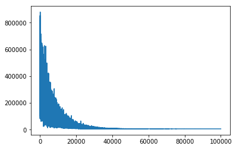

```python
pyro.clear_param_store()
guide = AutoDiagonalNormal(model)
loss = pyro.infer.Trace_ELBO()
optim = Adam({'lr':1e-4})
svi = pyro.infer.SVI(model, guide, optim, loss)
losses = []
n_steps = 100000
for s in range(n_steps):
    l = svi.step(observed_data)
    losses.append(l)
    if s % 10000 == 0:
        print("Loss:", l)

plt.plot(np.arange(n_steps), losses)
```

## Let's check we recovered $P(Y | do(X))$, i.e. $\delta Y \approx 4X$

```python
def get_interventional_treatment_effect(guide, value=0., n_samples=1000):
    t = [pyro.do(guide, {"x_z": value})()["g$$$lin.weight"] for _ in range(n_samples)]
    return torch.stack(t).flatten()
```

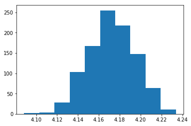

```python
plt.hist(get_interventional_treatment_effect(guide).detach().numpy())
```

# In sum

1. Pyro makes it easy to build probabilistic models
2. Deep model integration is straightforward
3. `pyro.do` allows you to easily simulate interventions *identified* models

For **deep causal modelling** this makes identification with functional estimation straightforward in one modelling step.